# Crime Reports in Seattle

## Motivation for the Project

Seattle, one of the most popular cities in the US, is known to have a high population.  
Due to its high population, crime is unavoidable in the city. Recognizing the concern, we desire to create a data visualization that visually conveys the type and location of reported crimes.

We are interested in the topic because identifying patterns in past crimes not only help professionals make informed decisions to combat the war with crime but also informs the general public about the critical information regarding public safety. Police officers, government officials, and others can use insights from this data to try implementing and enforcing different solutions to reduce crime rates. We believe that this type of data-driven decision making can have a positive impact on cities all around the world.

To obtain credible data, we collected our data sources are from Seattle.gov. The Seattle Police Department created all three data that we used for the project. Dataset 1 provides information about criminal incidents from 2008-present day, as well as the type of crime, its location, and how frequently that type occurs.

Crime Information by Sector

| Sectors | Total Primary Offenses | Most Occured Crime Frequency | Most Occured Crime | Number of Call Logs |
| --- | --- | --- | --- | --- |
| KING | 82 | 8 | Assault | 96 |
| MARY | 79 | 6 | Assault | 85 |
| BOY | 74 | 8 | Assault | 64 |
| QUEEN | 73 | 8 | Assault | 44 |
| DAVID | 71 | 9 | Assault | 73 |
| ROBERT | 71 | 9 | Assault | 73 |
| SAM | 60 | 8 | Homicide | 74 |
| UNION | 60 | 8 | Assault | 55 |
| LINCOLN | 56 | 9 | Assault | 48 |
| EDWARD | 53 | 8 | Assault | 54 |
| FRANK | 53 | 9 | Assault | 46 |
| GEORGE | 51 | 9 | Assault | 53 |
| NORA | 50 | 9 | Assault | 51 |
| JOHN | 39 | 9 | Assault | 44 |
| WILLIAM | 38 | 9 | Burglary | 53 |
| CHARLIE | 35 | 9 | Assault | 34 |
| OCEAN | 26 | 9 | Assault | 38 |

The aggregate data is collected from all three datasets:

- Data 1: [Seattle Crime Stats](https://data.seattle.gov/Public-Safety/Seattle-Crime-Stats-by-Police-Precinct-2008-Presen/3xqu-vnum)
- Data 2: [Call Data](https://data.seattle.gov/Public-Safety/Call-Data/33kz-ixgy)
- Data 3: [Crime Data](https://data.seattle.gov/Public-Safety/Crime-Data/4fs7-3vj5)

We chose these values - total primary offenses, most occured crime frequency, most occured crime, and number of call logs - as the columns to get an overview of the crime rate, reported rate (i.e. number of 911 calls), and type of most commonly reported crime prevelant in Seattle depending on the region (rows). We sorted the data by number of offenses descdending to see which sector is potentially the most dangerous/with the highest crime rate.

## Crime Report from 2008-present day

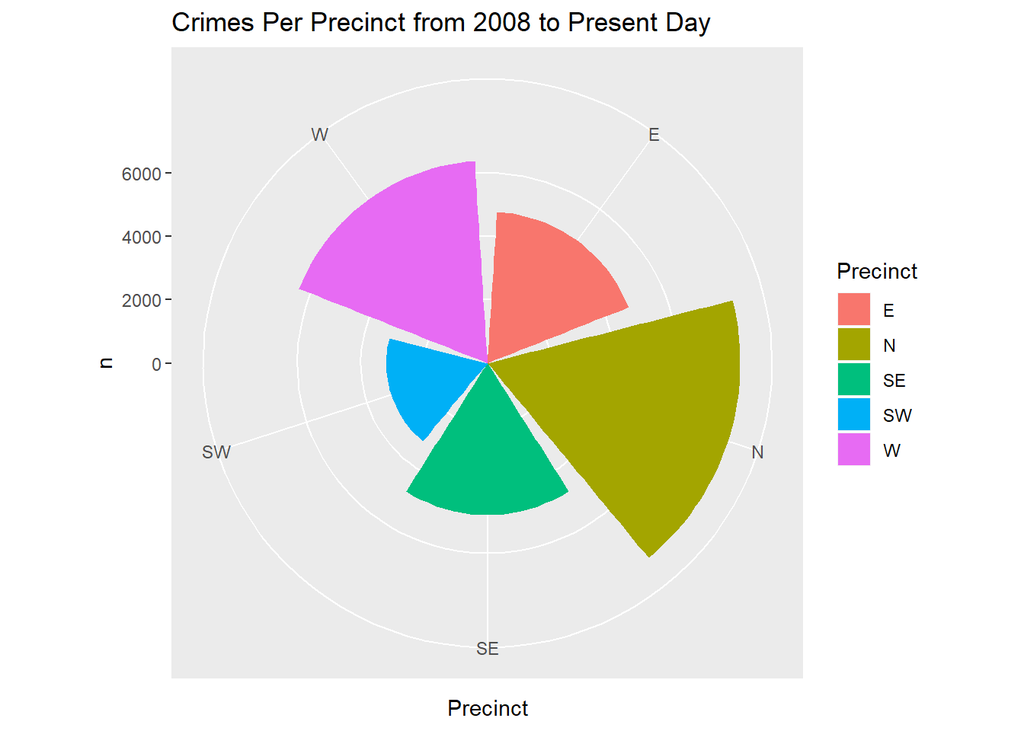

A precinct is an area whose boundaries are determined by the police for their investigative purposes. As indicated by this graph, the North precinct of Seattle is the most dangerous based on the number of crimes that have occured from 2008 to present day.

The second plot comes from the two dataset, Call Data joined with Crime Data, from Seattle Police Department as well. The Call Data records the Call Logs in the Communication Center. We chose this data to analyze whether the number of calls and number of crimes in each sector have a high correlation. The x-axis presents the individual sectors. The y-axis shows the ratio of crimes to calls recorded in the SPD’s database, calculated by dividing number of crimes in each sector divided by number of calls in each sector. From the color and size, it can be seen that a high crime rate generally leads to a high call rate. This suggests that a majority of the crimes get reported to 911 and other police communication in most sectors. An outlier shows that Queen has a relatively higher number of crime than calls logged in the database. On the other hand, Ocean sector has both low number of calls and low number of crimes in record.

## Relations of Crime and Call Data

#### (from SPD Communications Center)

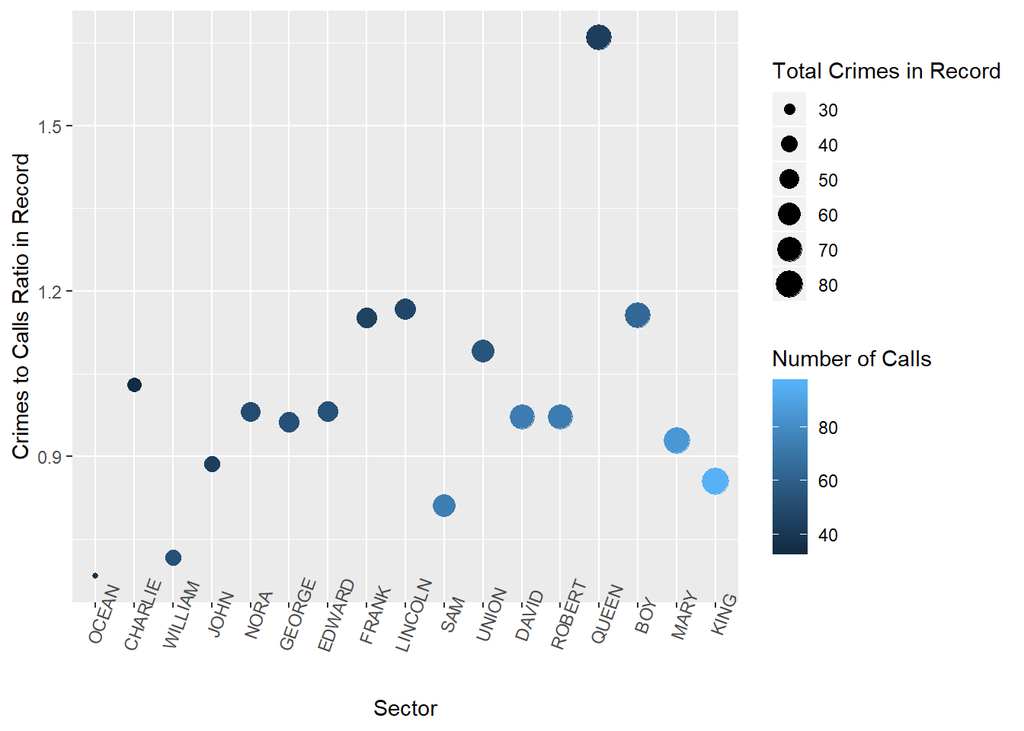

This data comes from The Seattle Police Department provided this data on the Seattle.gov website. It includes information about the crime that was reported in different neighborhoods in Seattle. There are total 524k rows, and 11 columns and each row is a unique crime reported record. The x-axis label of the graph represent the name of the location that crimes were reported and y axis label represent the number of crimes that were reported at each location. The visualization focused on the number of crime reports in different neighborhoods in Seattle. The visualization is represented as a bar graph, because the Bar graphs are useful when there are a high number of input groups such as the long list of neighborhood. The bar graph allows viewers to compare the number of reported crimes (y-axis) easily. The graph displays that Downtown Seattle has the highest rate of crime reported, Northgate and Capitol Hill has the higest rate following. The city with the lowest crime rate is Commercial Harbor Island. The numbers of crimes are proportionally distributed across the areas.

## Number of Crime Reports in Seattle Neighborhood

[interactive chart not shown]